# The Effects of Climate Change on the Breeding Success and Timing of African White Backed Vultures.

Author

Mieke Deyzel

**Clean Data**

### Aim and Objectives

The project aims to investigate how weather variation affects the breeding timing and success of African White Backed Vultures over 31 years. To address this, three broad objectives and sub-questions were identified:

To determine whether annual variation in climatic conditions is associated with breeding effort Is the total number of active nests (both failed and successful) each year associated with variation in weather conditions? We hypothesise that variation in climatic conditions will influence the number of active nests observed annually. In years with significant fluctuations in weather events and climatic extremes, there will be a lower number of active nests.

To determine whether climatic conditions predict variation in yearly breeding success Is annual variation in weather associated with breeding success, measured as the proportion of active nests that produce a fledgling? We hypothesise that annual variation in climatic conditions will influence the proportion of successful nests per annum. Moderate fluctuations in climatic conditions and the absence of extreme weather events such as hailstorms will increase the proportion of successful breeding, leading to more annual fledglings.

To assess whether climatic conditions predict the timing of breeding Is the timing of fledging associated with climatic conditions during the breeding season? We hypothesise that the time of fledging will be correlated with the annual variation in climatic conditions. Preferred weather conditions, such as moderate temperatures, will result in earlier breeding of the vultures compared to more extreme conditions.

#### Load in libraries

```r
#| message: false
#| warning: false
library(tidyverse)
library(lubridate)
library(janitor)
library(stringr)
library(car)         # Durbin–Watson
library(MASS)        # glm.nb
library(patchwork)
theme_set(theme_bw())
```

### Load in Breeding and Weather Data

```r
vultures <- read.csv("~/Desktop/Vulture Project/Data/93_24 cleaned.csv")
WeatherData <- read.csv("~/Desktop/Vulture Project/Data/Weather.csv")
```

```r
# Clean names, standardise separators
vultures <- vultures |>
  clean_names() |>
  rename_with(~ gsub("_", ".", .x))

# Dates
vultures <- vultures |>
  mutate(
    ringing.date = ymd(gsub("/", "-", ringing.date)),
    laying.date  = laying.date |> as.character() |> str_trim(),
    laying.date  = if_else(laying.date %in% c("", "NA", "?"), NA_character_, laying.date),
    laying.date  = ymd(gsub("/", "-", laying.date))
  )

# Keep records with a real ringing date
vultures.clean <- vultures |>
  filter(!is.na(ringing.date))
```

Weather summaries (annual & daily)

```r
# Annual summaries for joining to yearly analyses (Obj.1 & Obj.2)
weather_yearly <- WeatherData |>
  filter(YEAR >= 1992, YEAR <= 2024) |>
  group_by(YEAR) |>
  summarise(
    mean_temp  = mean(TEMP, na.rm = TRUE),
    max_temp   = max(MAX,  na.rm = TRUE),
    min_temp   = min(MIN,  na.rm = TRUE),
    total_rain = sum(PRCP, na.rm = TRUE),
    max_rain   = max(PRCP, na.rm = TRUE),              # wettest day
    rain_days  = sum(PRCP > 0, na.rm = TRUE),          # count of rainy days
    mean_wind  = mean(WDSP, na.rm = TRUE),
    max_wind   = max(MXSPD, na.rm = TRUE),
    hail_days  = sum(I_HAIL, na.rm = TRUE),
    .groups = "drop"
  )

# Lagged versions of the annual weather summaries
weather_yearly_lag <- weather_yearly |>
  arrange(YEAR) |>
  mutate(
    across(c(mean_temp, max_temp, min_temp, total_rain, max_rain,
             rain_days, mean_wind, max_wind, hail_days),
           ~ dplyr::lag(.x, 1), .names = "lag_{.col}")
  )


# Daily table for pre-laying windows (Obj.3)
weather_df <- WeatherData |>
  mutate(
    date      = make_date(YEAR, MONTH, DAY),
    mean_temp = readr::parse_number(as.character(TEMP)),
    max_temp  = readr::parse_number(as.character(MAX)),
    min_temp  = readr::parse_number(as.character(MIN)),
    mean_wind = readr::parse_number(as.character(WDSP)),
    max_wind  = readr::parse_number(as.character(MXSPD)),
    rain      = readr::parse_number(as.character(PRCP)),
    rain_day  = as.integer(replace_na(rain, 0) > 0)
  ) |>
  arrange(date)
```

**Objective 1: Breeding effort (active nests)**

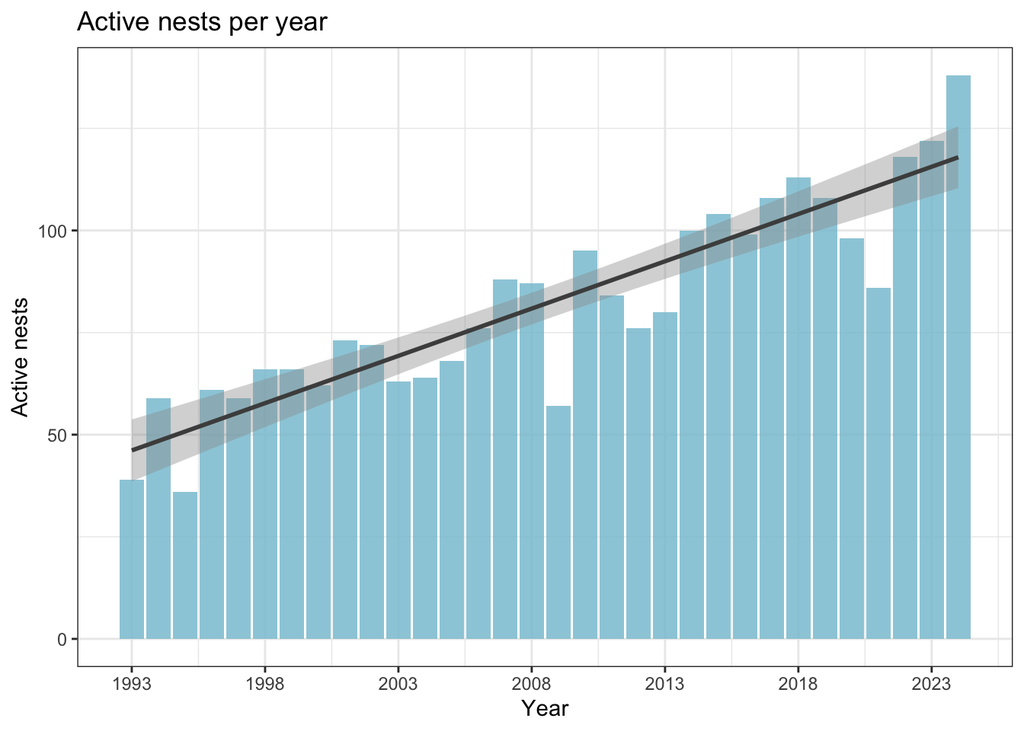

```r
# Annual active nests
active.nests <- vultures.clean |>
  mutate(year = year(ringing.date)) |>
  group_by(year) |>
  summarise(active_nests = n(), .groups = "drop")

# Join weather to effort
effort_weather <- active.nests |>
  left_join(weather_yearly, by = c("year" = "YEAR"))

# Visual
ggplot(active.nests, aes(year, active_nests)) +
  geom_col(fill = "#89c5d6", alpha = 0.85) +
  geom_smooth(method = "lm", se = TRUE, colour = "grey30", linewidth = 1) +
  scale_x_continuous(breaks = seq(min(active.nests$year), max(active.nests$year), 5)) +
  labs(title = "Active nests per year", x = "Year", y = "Active nests")
```

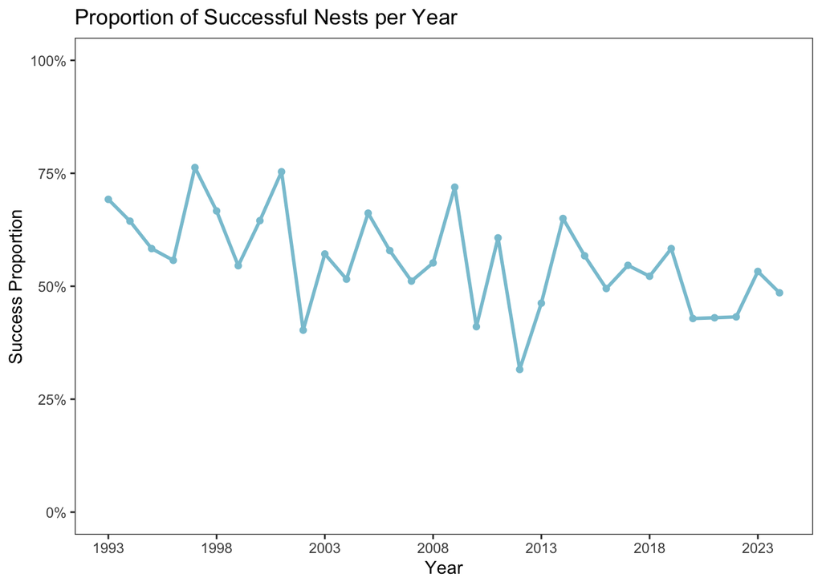

```r
failed.nests <- vultures.clean |>
  mutate(year = year(ringing.date)) |>
  group_by(year) |>
  summarise(
    active_nests  = n(),
    success_nests = sum(!is.na(laying.date)),
    failed_nests  = active_nests - success_nests,
    success_prop  = success_nests / active_nests,
    .groups = "drop"
  )
ggplot(failed.nests, aes(x = year, y = success_prop)) +
  geom_line(color = "#89c5d6", linewidth = 1) +
  geom_point(color = "#89c5d6") +
  scale_x_continuous(breaks = seq(min(failed.nests$year), max(failed.nests$year), by = 5)) +
  scale_y_continuous(limits = c(0, 1),
                     labels = scales::percent_format(accuracy = 1)) +
  labs(title = "Proportion of Successful Nests per Year", x = "Year", y = "Success Proportion") +
  theme_bw() +
  theme(panel.grid = element_blank())
```

### Negative Binomial GLM

```r
# Negative Binomial GLM
effort_model <- glm.nb(
  active_nests ~ mean_temp + max_temp + min_temp +
    total_rain + max_rain + rain_days + mean_wind + max_wind + hail_days + year,
  data = effort_weather
)
summary(effort_model)
```

```
Call:
glm.nb(formula = active_nests ~ mean_temp + max_temp + min_temp +
    total_rain + max_rain + rain_days + mean_wind + max_wind +
    hail_days + year, data = effort_weather, init.theta = 782490.2886,
    link = log)

Coefficients:
              Estimate Std. Error z value Pr(>|z|)
(Intercept) -5.226e+01  5.306e+00  -9.849   <2e-16 ***
mean_temp    4.793e-02  3.482e-02   1.376   0.1687
max_temp     8.955e-03  1.303e-02   0.688   0.4918
min_temp     1.498e-02  1.575e-02   0.951   0.3415
total_rain   3.800e-05  7.602e-05   0.500   0.6171
max_rain    -2.650e-03  1.185e-03  -2.237   0.0253 *
rain_days    1.162e-03  1.835e-03   0.633   0.5264
mean_wind    3.366e-02  6.304e-02   0.534   0.5933
max_wind    -2.210e-03  5.476e-03  -0.404   0.6866
hail_days   -7.969e-03  1.551e-02  -0.514   0.6074
year         2.760e-02  2.635e-03  10.474   <2e-16 ***
---
Signif. codes:  0 '***' 0.001 '**' 0.01 '*' 0.05 '.' 0.1 ' ' 1

(Dispersion parameter for Negative Binomial(782490.3) family taken to be 1)

    Null deviance: 222.628  on 31  degrees of freedom
Residual deviance:  31.665  on 21  degrees of freedom
AIC: 254.15

Number of Fisher Scoring iterations: 1

              Theta:  782490
          Std. Err.:  27950820
Warning while fitting theta: iteration limit reached

 2 x log-likelihood:  -230.152
```

```r
logLik(effort_model)
```

```
'log Lik.' -115.0762 (df=12)
```

### Lagged effects

```r
# Join active nests with lagged weather
effort_weather_lag <- active.nests |>
  left_join(weather_yearly_lag, by = c("year" = "YEAR"))

# Minimal, stable lag model (adds year to control for trend)
effort_nb_lag <- MASS::glm.nb(
  active_nests ~ lag_total_rain + lag_mean_temp + lag_mean_wind + lag_hail_days + year,
  data = effort_weather_lag,
  control = glm.control(maxit = 100), init.theta = 1
)
summary(effort_nb_lag)
```

```
Call:
MASS::glm.nb(formula = active_nests ~ lag_total_rain + lag_mean_temp +
    lag_mean_wind + lag_hail_days + year, data = effort_weather_lag,
    control = glm.control(maxit = 100), init.theta = 326.427347,
    link = log)

Coefficients:
                 Estimate Std. Error z value Pr(>|z|)
(Intercept)    -5.182e+01  6.129e+00  -8.455   <2e-16 ***
lag_total_rain -1.546e-05  5.110e-05  -0.303    0.762
lag_mean_temp  -1.688e-02  2.813e-02  -0.600    0.549
lag_mean_wind  -3.290e-02  6.039e-02  -0.545    0.586
lag_hail_days  -5.040e-03  1.756e-02  -0.287    0.774
year            2.820e-02  2.922e-03   9.650   <2e-16 ***
---
Signif. codes:  0 '***' 0.001 '**' 0.01 '*' 0.05 '.' 0.1 ' ' 1

(Dispersion parameter for Negative Binomial(326.4273) family taken to be 1)

    Null deviance: 178.543  on 31  degrees of freedom
Residual deviance:  34.066  on 26  degrees of freedom
AIC: 253.67

Number of Fisher Scoring iterations: 1

              Theta:  326
          Std. Err.:  423

 2 x log-likelihood:  -239.673
```

```r
# Compare to current-year model by AIC
AIC(effort_model, effort_nb_lag)
```

```
              df      AIC
effort_model  12 254.1524
effort_nb_lag  7 253.6733
```

**Objective 2: Breeding success (proportion)**

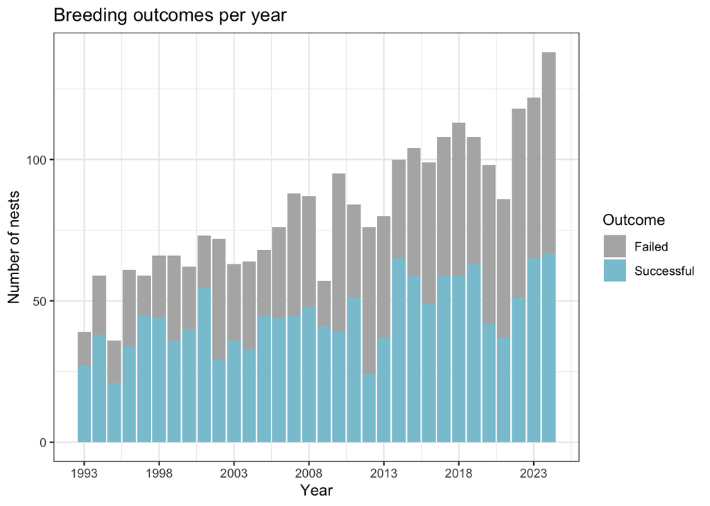

```r
# Annual successes/failures
failed.nests <- vultures.clean |>
  mutate(year = year(ringing.date)) |>
  group_by(year) |>
  summarise(
    active_nests  = n(),
    success_nests = sum(!is.na(laying.date)),
    failed_nests  = active_nests - success_nests,
    success_prop  = success_nests / active_nests,
    .groups = "drop"
  )

# Outcome visual
failed_nests_long <- failed.nests |>
  dplyr::select(year, success_nests, failed_nests) |>
  tidyr::pivot_longer(
    cols = c(success_nests, failed_nests),
    names_to = "outcome",
    values_to = "count"
  )

ggplot(failed_nests_long, aes(year, count, fill = outcome)) +
  geom_col() +
  scale_fill_manual(values = c(success_nests = "#89c5d6", failed_nests = "grey70"),
                    labels = c(success_nests = "Successful", failed_nests = "Failed")) +
  scale_x_continuous(breaks = seq(min(failed.nests$year), max(failed.nests$year), 5)) +
  labs(title = "Breeding outcomes per year", x = "Year", y = "Number of nests", fill = "Outcome")
```

```r
# Join weather; scale predictors for stability
success_df <- failed.nests |>
  left_join(weather_yearly, by = c("year" = "YEAR")) |>
  mutate(
    across(c(mean_temp, max_temp, min_temp, total_rain, max_rain,
             rain_days, mean_wind, max_wind, hail_days),
           ~ as.numeric(scale(.x)), .names = "z_{.col}")
  )

# Quasi-binomial GLM (handles overdispersion)
success_model_quasi <- glm(
  cbind(success_nests, failed_nests) ~
    z_mean_temp + z_max_temp + z_min_temp +
    z_total_rain + z_max_rain + z_rain_days +
    z_mean_wind + z_max_wind + z_hail_days + year,
  family = quasibinomial,
  data = success_df
)
summary(success_model_quasi)
```

```
Call:
glm(formula = cbind(success_nests, failed_nests) ~ z_mean_temp +
    z_max_temp + z_min_temp + z_total_rain + z_max_rain + z_rain_days +
    z_mean_wind + z_max_wind + z_hail_days + year, family = quasibinomial,
    data = success_df)

Coefficients:
              Estimate Std. Error t value Pr(>|t|)
(Intercept)  43.162007  18.382724   2.348   0.0288 *
z_mean_temp   0.033275   0.100603   0.331   0.7441
z_max_temp   -0.057114   0.097534  -0.586   0.5644
z_min_temp    0.147839   0.084163   1.757   0.0936 .
z_total_rain -0.020053   0.123313  -0.163   0.8724
z_max_rain    0.016557   0.113877   0.145   0.8858
z_rain_days  -0.069332   0.097024  -0.715   0.4827
z_mean_wind   0.004824   0.084453   0.057   0.9550
z_max_wind   -0.031501   0.090719  -0.347   0.7319
z_hail_days  -0.032800   0.073235  -0.448   0.6588
year         -0.021374   0.009145  -2.337   0.0294 *
---
Signif. codes:  0 '***' 0.001 '**' 0.01 '*' 0.05 '.' 0.1 ' ' 1

(Dispersion parameter for quasibinomial family taken to be 2.876008)

    Null deviance: 107.689  on 31  degrees of freedom
Residual deviance:  61.319  on 21  degrees of freedom
AIC: NA

Number of Fisher Scoring iterations: 3
```

```r
# Effect of minimum temperature (holding others at 0)
newdat_minT <- tibble(
  z_min_temp  = seq(min(success_df$z_min_temp, na.rm = TRUE),
                    max(success_df$z_min_temp, na.rm = TRUE), length.out = 200),
  z_mean_temp = 0, z_max_temp = 0, z_total_rain = 0, z_max_rain = 0,
  z_rain_days = 0, z_mean_wind = 0, z_max_wind = 0, z_hail_days = 0,
  year = mean(success_df$year, na.rm = TRUE)
)

pred <- predict(success_model_quasi, newdata = newdat_minT, type = "link", se.fit = TRUE)
newdat_minT <- newdat_minT |>
  mutate(p = plogis(pred$fit),
         lwr = plogis(pred$fit - 1.96*pred$se.fit),
         upr = plogis(pred$fit + 1.96*pred$se.fit))

plot_minT <- ggplot(newdat_minT, aes(z_min_temp, p)) +
  geom_ribbon(aes(ymin = lwr, ymax = upr), alpha = 0.15) +
  geom_line(linewidth = 1.2, colour = "#2C7BB6") +
  labs(x = "Minimum temperature (scaled)", y = "Predicted breeding success",
       title = "Effect of warmer nights on breeding success")
```

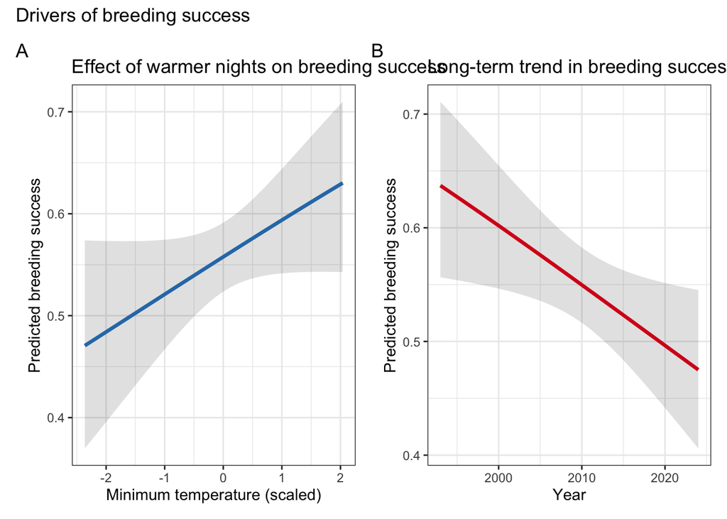

```r
# Long-term trend in success
newdat_year <- tibble(
  year = seq(min(success_df$year), max(success_df$year), length.out = 200),
  z_mean_temp = 0, z_max_temp = 0, z_min_temp = 0, z_total_rain = 0, z_max_rain = 0,
  z_rain_days = 0, z_mean_wind = 0, z_max_wind = 0, z_hail_days = 0
)

pred_year <- predict(success_model_quasi, newdata = newdat_year, type = "link", se.fit = TRUE)
newdat_year <- newdat_year |>
  mutate(p = plogis(pred_year$fit),
         lwr = plogis(pred_year$fit - 1.96*pred_year$se.fit),
         upr = plogis(pred_year$fit + 1.96*pred_year$se.fit))

plot_year <- ggplot(newdat_year, aes(year, p)) +
  geom_ribbon(aes(ymin = lwr, ymax = upr), alpha = 0.15) +
  geom_line(linewidth = 1.2, colour = "#D7191C") +
  labs(x = "Year", y = "Predicted breeding success",
       title = "Long-term trend in breeding success")

# Side-by-side
(plot_minT | plot_year) + plot_annotation(title = "Drivers of breeding success", tag_levels = "A")
```

### Lagged weather effects

```r
# Join successes with lagged weathers
success_df_lag <- failed.nests |>
  left_join(weather_yearly_lag, by = c("year" = "YEAR")) |>
  mutate(
    across(c(lag_mean_temp, lag_max_temp, lag_min_temp, lag_total_rain, lag_max_rain,
             lag_rain_days, lag_mean_wind, lag_max_wind, lag_hail_days),
           ~ as.numeric(scale(.x)), .names = "z_{.col}")
  )

success_lag_quasi <- glm(
  cbind(success_nests, failed_nests) ~
    z_lag_mean_temp + z_lag_min_temp + z_lag_max_temp +
    z_lag_total_rain + z_lag_max_rain + z_lag_rain_days +
    z_lag_mean_wind + z_lag_max_wind + z_lag_hail_days +
    year,
  family = quasibinomial,
  data = success_df_lag
)
summary(success_lag_quasi)
```

```
Call:
glm(formula = cbind(success_nests, failed_nests) ~ z_lag_mean_temp +
    z_lag_min_temp + z_lag_max_temp + z_lag_total_rain + z_lag_max_rain +
    z_lag_rain_days + z_lag_mean_wind + z_lag_max_wind + z_lag_hail_days +
    year, family = quasibinomial, data = success_df_lag)

Coefficients:
                  Estimate Std. Error t value Pr(>|t|)
(Intercept)      48.447688  19.815163   2.445   0.0234 *
z_lag_mean_temp  -0.024258   0.103928  -0.233   0.8177
z_lag_min_temp   -0.044908   0.081586  -0.550   0.5878
z_lag_max_temp   -0.009756   0.095911  -0.102   0.9199
z_lag_total_rain  0.154174   0.124466   1.239   0.2291
z_lag_max_rain   -0.101682   0.110405  -0.921   0.3675
z_lag_rain_days  -0.163313   0.110133  -1.483   0.1530
z_lag_mean_wind  -0.008090   0.088541  -0.091   0.9281
z_lag_max_wind   -0.106251   0.090615  -1.173   0.2541
z_lag_hail_days  -0.030550   0.077723  -0.393   0.6982
year             -0.023997   0.009857  -2.434   0.0239 *
---
Signif. codes:  0 '***' 0.001 '**' 0.01 '*' 0.05 '.' 0.1 ' ' 1

(Dispersion parameter for quasibinomial family taken to be 3.065651)

    Null deviance: 107.689  on 31  degrees of freedom
Residual deviance:  65.127  on 21  degrees of freedom
AIC: NA

Number of Fisher Scoring iterations: 4
```

```r
# (Tip) Quasi-binomial has no AIC; judge by effect sizes, SEs, and residual deviance/df.
disp_ratio_lag <- deviance(success_lag_quasi) / df.residual(success_lag_quasi)
disp_ratio_lag
```

```
[1] 3.101271
```

**Objective 3: Breeding timing (laying date)**

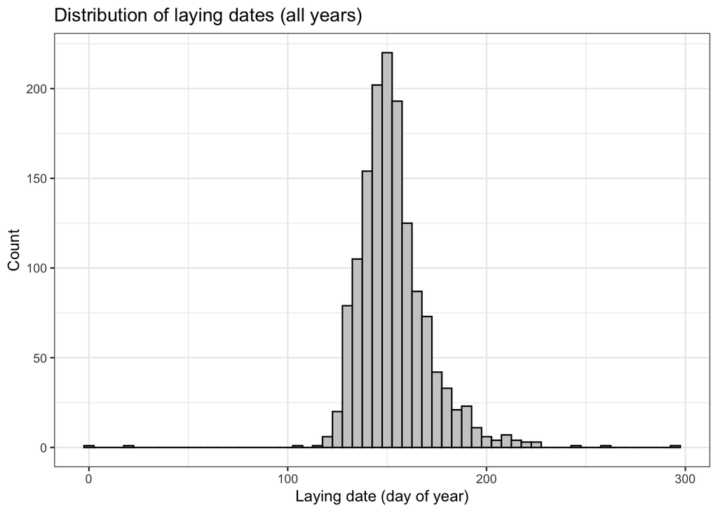

```r
# Per-record timing
timing_df <- vultures.clean |>
  filter(!is.na(laying.date)) |>
  mutate(
    lay_DOY = yday(laying.date),
    year    = year(laying.date)
  )

# Histogram
ggplot(timing_df, aes(lay_DOY)) +
  geom_histogram(binwidth = 5, colour = "black", fill = "grey80") +
  labs(title = "Distribution of laying dates (all years)",
       x = "Laying date (day of year)", y = "Count")
```

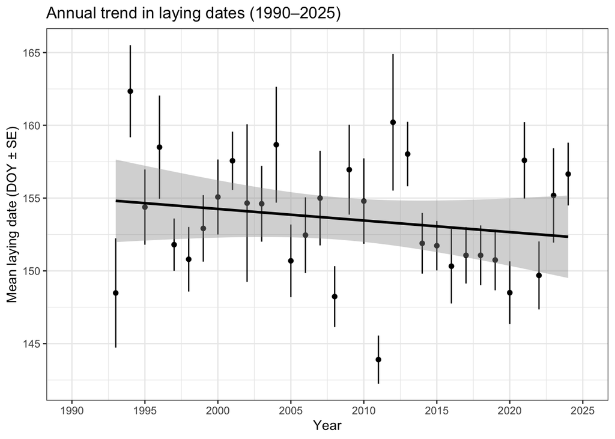

```r
# Annual means ± SE (showing 1990–2025 frame)
annual_timing <- timing_df |>
  group_by(year) |>
  summarise(
    n = n(),
    mean_DOY = mean(lay_DOY, na.rm = TRUE),
    se_DOY   = sd(lay_DOY, na.rm = TRUE) / sqrt(n),
    .groups = "drop"
  )

full_years <- tibble(year = 1990:2025)
annual_timing_full <- full_years |> left_join(annual_timing, by = "year")

ggplot(annual_timing_full, aes(year, mean_DOY)) +
  geom_point(na.rm = TRUE) +
  geom_errorbar(aes(ymin = mean_DOY - se_DOY, ymax = mean_DOY + se_DOY),
                width = 0, na.rm = TRUE) +
  geom_smooth(method = "lm", se = TRUE, colour = "black", na.rm = TRUE) +
  scale_x_continuous(breaks = seq(1990, 2025, 5), limits = c(1990, 2025)) +
  labs(title = "Annual trend in laying dates (1990–2025)",
       x = "Year", y = "Mean laying date (DOY ± SE)")
```

```r
# Full annual-weather timing model (screening)
timing_weather <- timing_df |>
  left_join(weather_yearly, by = c("year" = "YEAR"))

timing_weather_full <- lm(
  lay_DOY ~ mean_temp + max_temp + min_temp +
    total_rain + max_rain + rain_days + mean_wind + max_wind + hail_days + year,
  data = timing_weather
)
summary(timing_weather_full)
```

```
Call:
lm(formula = lay_DOY ~ mean_temp + max_temp + min_temp + total_rain +
    max_rain + rain_days + mean_wind + max_wind + hail_days +
    year, data = timing_weather)

Residuals:
     Min       1Q   Median       3Q      Max
-134.406  -10.365   -2.789    7.597  143.517

Coefficients:
              Estimate Std. Error t value Pr(>|t|)
(Intercept) 170.974632 125.523336   1.362   0.1734
mean_temp    -0.398322   0.814157  -0.489   0.6247
max_temp      0.021004   0.322923   0.065   0.9481
min_temp     -0.499543   0.382349  -1.307   0.1916
total_rain    0.001248   0.001796   0.695   0.4873
max_rain     -0.004144   0.027182  -0.152   0.8789
rain_days    -0.082624   0.041883  -1.973   0.0487 *
mean_wind     0.841075   1.531126   0.549   0.5829
max_wind      0.252361   0.131806   1.915   0.0557 .
hail_days    -0.579919   0.379618  -1.528   0.1268
year         -0.007693   0.063269  -0.122   0.9032
---
Signif. codes:  0 '***' 0.001 '**' 0.01 '*' 0.05 '.' 0.1 ' ' 1

Residual standard error: 17.67 on 1416 degrees of freedom
  (1 observation deleted due to missingness)
Multiple R-squared:  0.01521,   Adjusted R-squared:  0.008251
F-statistic: 2.186 on 10 and 1416 DF,  p-value: 0.01639
```

```r
# Simplified (best annual terms)
timing_weather_simple <- lm(lay_DOY ~ rain_days + max_wind + year, data = timing_weather)
summary(timing_weather_simple)
```

```
Call:
lm(formula = lay_DOY ~ rain_days + max_wind + year, data = timing_weather)

Residuals:
     Min       1Q   Median       3Q      Max
-135.289  -10.452   -2.932    7.200  144.382

Coefficients:
             Estimate Std. Error t value Pr(>|t|)
(Intercept) 244.92496  108.04933   2.267  0.02355 *
rain_days    -0.04975    0.02988  -1.665  0.09620 .
max_wind      0.33389    0.10841   3.080  0.00211 **
year         -0.04675    0.05340  -0.875  0.38151
---
Signif. codes:  0 '***' 0.001 '**' 0.01 '*' 0.05 '.' 0.1 ' ' 1

Residual standard error: 17.68 on 1423 degrees of freedom
  (1 observation deleted due to missingness)
Multiple R-squared:  0.009429,  Adjusted R-squared:  0.007341
F-statistic: 4.515 on 3 and 1423 DF,  p-value: 0.003695
```

```r
# 60-day pre-laying windows (daily weather)
summarise_60 <- function(lay_date, weather) {
  w <- weather |> filter(date > (lay_date - days(60)), date <= lay_date)
  tibble(
    mean_temp_60  = mean(w$mean_temp, na.rm = TRUE),
    max_temp_60   = mean(w$max_temp,  na.rm = TRUE),
    min_temp_60   = mean(w$min_temp,  na.rm = TRUE),
    total_rain_60 = sum(w$rain,       na.rm = TRUE),
    rain_days_60  = sum(w$rain_day,   na.rm = TRUE),
    mean_wind_60  = mean(w$mean_wind, na.rm = TRUE),
    max_wind_60   = mean(w$max_wind,  na.rm = TRUE)
  )
}

timing_weather_60 <- timing_df |>
  mutate(.win = purrr::map(laying.date, summarise_60, weather = weather_df)) |>
  unnest(.win)

timing_weather_60_model <- lm(lay_DOY ~ rain_days_60 + max_wind_60 + year, data = timing_weather_60)
summary(timing_weather_60_model)
```

```
Call:
lm(formula = lay_DOY ~ rain_days_60 + max_wind_60 + year, data = timing_weather_60)

Residuals:
     Min       1Q   Median       3Q      Max
-102.465   -9.497   -2.087    7.292  133.790

Coefficients:
             Estimate Std. Error t value Pr(>|t|)
(Intercept)  64.65385   91.34146   0.708  0.47917
rain_days_60 -1.45730    0.06119 -23.816  < 2e-16 ***
max_wind_60  -1.97646    0.70385  -2.808  0.00505 **
year          0.05830    0.04503   1.295  0.19561
---
Signif. codes:  0 '***' 0.001 '**' 0.01 '*' 0.05 '.' 0.1 ' ' 1

Residual standard error: 14.97 on 1423 degrees of freedom
  (1 observation deleted due to missingness)
Multiple R-squared:  0.2895,    Adjusted R-squared:  0.288
F-statistic: 193.3 on 3 and 1423 DF,  p-value: < 2.2e-16
```

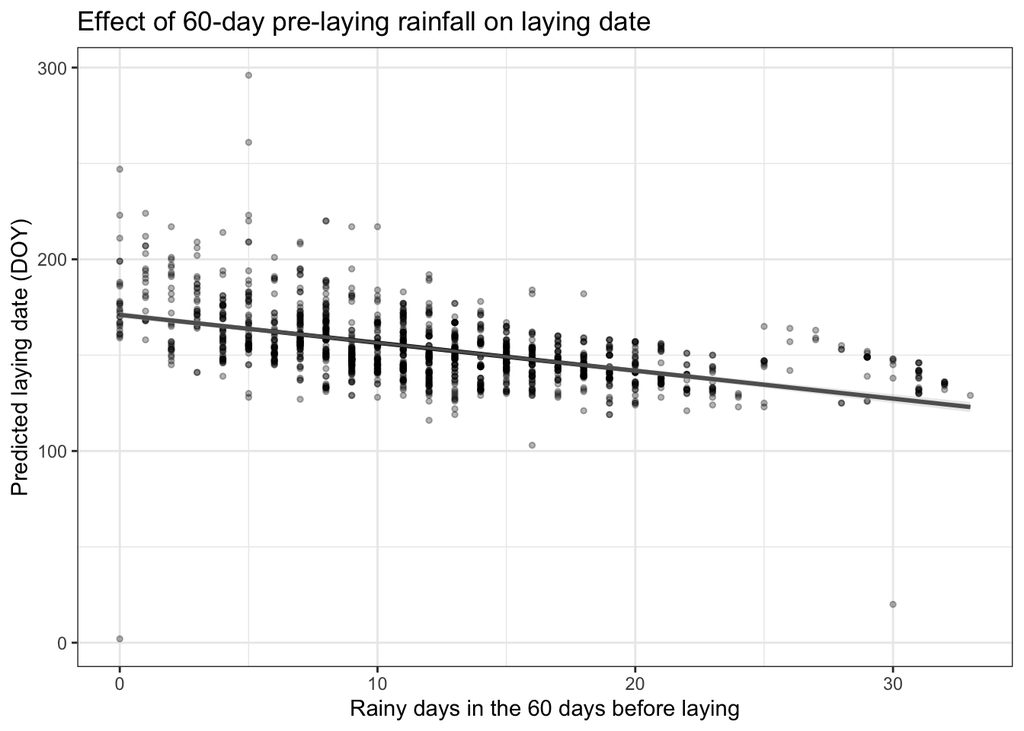

```r
# Plot predicted effect of rainy days (60-day window)
new_rain60 <- tibble(
  rain_days_60 = seq(min(timing_weather_60$rain_days_60, na.rm = TRUE),
                     max(timing_weather_60$rain_days_60, na.rm = TRUE), length.out = 100),
  max_wind_60  = mean(timing_weather_60$max_wind_60, na.rm = TRUE),
  year         = mean(timing_weather_60$year, na.rm = TRUE)
)

pred <- predict(timing_weather_60_model, newdata = new_rain60, se.fit = TRUE)
new_rain60 <- new_rain60 |>
  mutate(fit = pred$fit, lwr = pred$fit - 1.96*pred$se.fit, upr = pred$fit + 1.96*pred$se.fit)

ggplot() +
  geom_point(data = timing_weather_60, aes(rain_days_60, lay_DOY), alpha = 0.3, size = 1) +
  geom_line(data = new_rain60, aes(rain_days_60, fit), colour = "black", linewidth = 1) +
  geom_ribbon(data = new_rain60, aes(rain_days_60, ymin = lwr, ymax = upr), fill = "grey80", alpha = 0.4) +
  labs(title = "Effect of 60-day pre-laying rainfall on laying date",
       x = "Rainy days in the 60 days before laying", y = "Predicted laying date (DOY)")
```

**Autocorrelation checks (residual independence)**

```r
# Obj.1 Effort (NB GLM)
car::durbinWatsonTest(effort_model)
```

```
 lag Autocorrelation D-W Statistic p-value
   1      -0.2537157      2.472122       0
 Alternative hypothesis: rho != 0
```

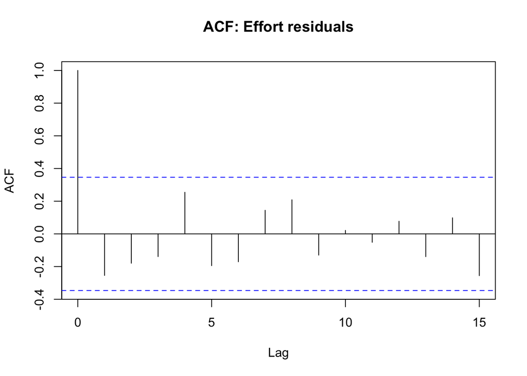

```r
acf(resid(effort_model), main = "ACF: Effort residuals")
```

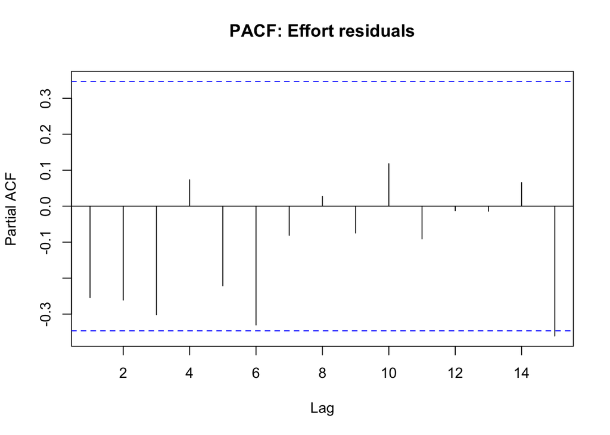

```r
pacf(resid(effort_model), main = "PACF: Effort residuals")
```

```r
# Obj.2 Success (quasi-binomial GLM)
car::durbinWatsonTest(success_model_quasi)
```

```
 lag Autocorrelation D-W Statistic p-value
   1      -0.3177015      2.624635   0.192
 Alternative hypothesis: rho != 0
```

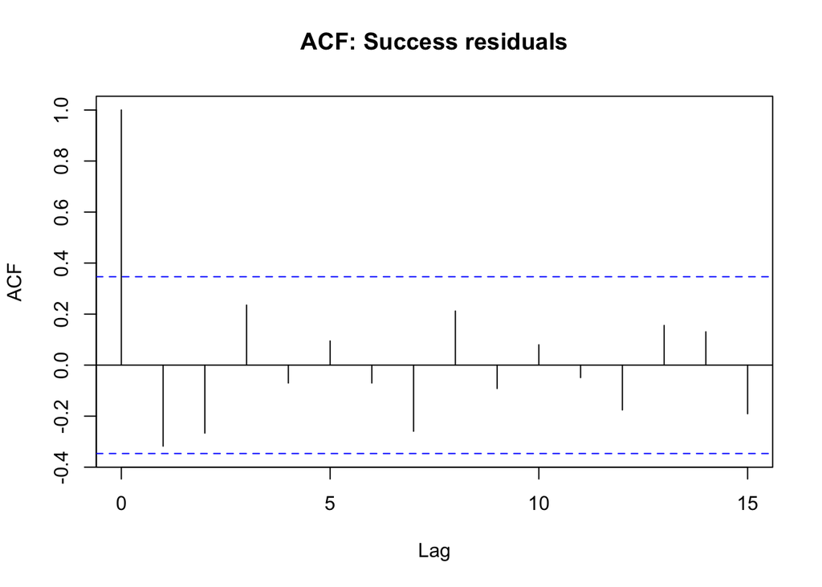

```r
acf(resid(success_model_quasi), main = "ACF: Success residuals")
```

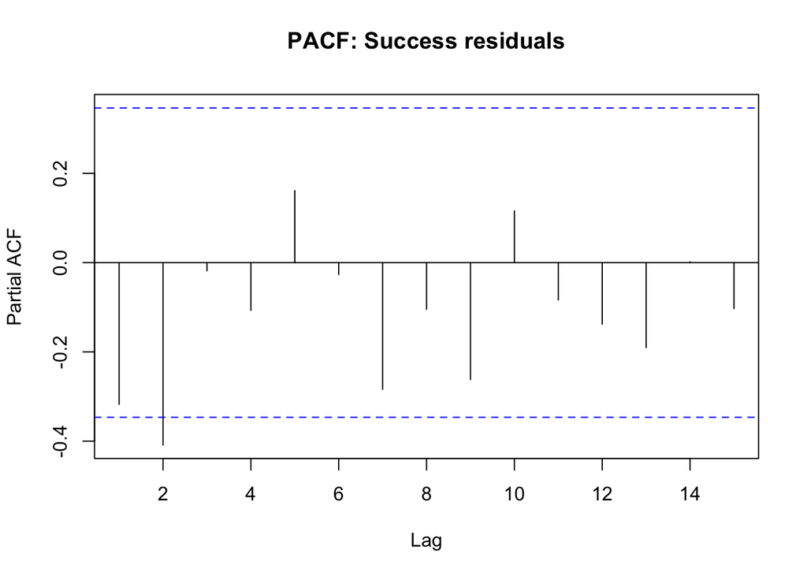

```r
pacf(resid(success_model_quasi), main = "PACF: Success residuals")
```

```r
# Obj.3 Timing — raw annual series (detrend & test)
annual_timing_clean <- timing_df |>
  group_by(year) |>
  summarise(mean_DOY = mean(lay_DOY, na.rm = TRUE), .groups = "drop") |>
  filter(!is.na(mean_DOY)) |>
  arrange(year)

timing_lm <- lm(mean_DOY ~ year, data = annual_timing_clean)
car::durbinWatsonTest(timing_lm)
```

```
 lag Autocorrelation D-W Statistic p-value
   1       0.6106079     0.5758001       0
 Alternative hypothesis: rho != 0
```

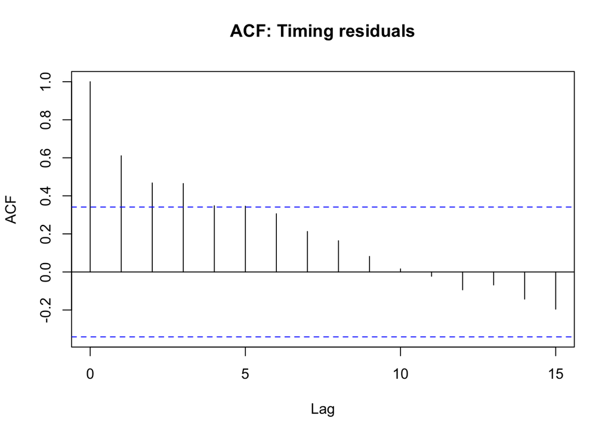

```r
acf(resid(timing_lm), main = "ACF: Timing residuals")
```

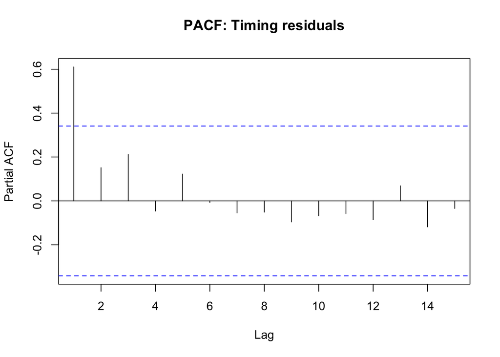

```r
pacf(resid(timing_lm), main = "PACF: Timing residuals")
```

```r
# Obj.3 Timing — 60-day model residuals
car::durbinWatsonTest(timing_weather_60_model)
```

```
 lag Autocorrelation D-W Statistic p-value
   1       0.1820669      1.632535       0
 Alternative hypothesis: rho != 0
```

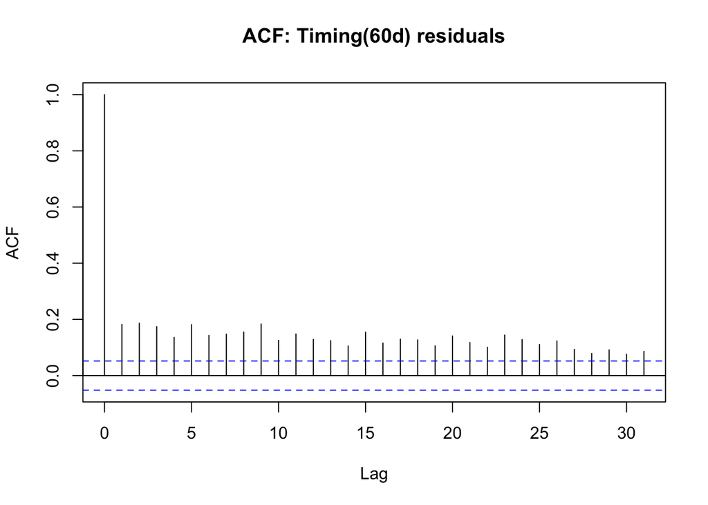

```r
acf(resid(timing_weather_60_model), main = "ACF: Timing(60d) residuals")
```

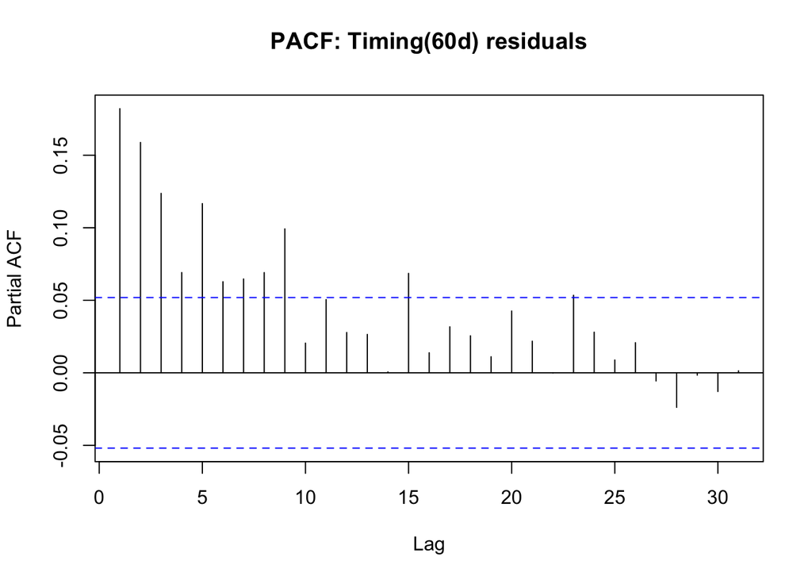

```r
pacf(resid(timing_weather_60_model), main = "PACF: Timing(60d) residuals")
```

**Attempt 2**

**Objective 1**

### Year

```r
library(MASS)

# Annual active nests (you already have this)
active.nests <- vultures.clean |>
  mutate(year = lubridate::year(ringing.date)) |>
  group_by(year) |>
  summarise(active_nests = n(), .groups = "drop")

# Year-only Negative Binomial model
m_year <- glm.nb(active_nests ~ year, data = active.nests)
summary(m_year)
```

```
Call:
glm.nb(formula = active_nests ~ year, data = active.nests, init.theta = 283.4337529,
    link = log)

Coefficients:
              Estimate Std. Error z value Pr(>|z|)
(Intercept) -53.188260   4.927882  -10.79   <2e-16 ***
year          0.028659   0.002451   11.69   <2e-16 ***
---
Signif. codes:  0 '***' 0.001 '**' 0.01 '*' 0.05 '.' 0.1 ' ' 1

(Dispersion parameter for Negative Binomial(283.4338) family taken to be 1)

    Null deviance: 173.368  on 31  degrees of freedom
Residual deviance:  34.003  on 30  degrees of freedom
AIC: 246.56

Number of Fisher Scoring iterations: 1

              Theta:  283
          Std. Err.:  329

 2 x log-likelihood:  -240.558
```

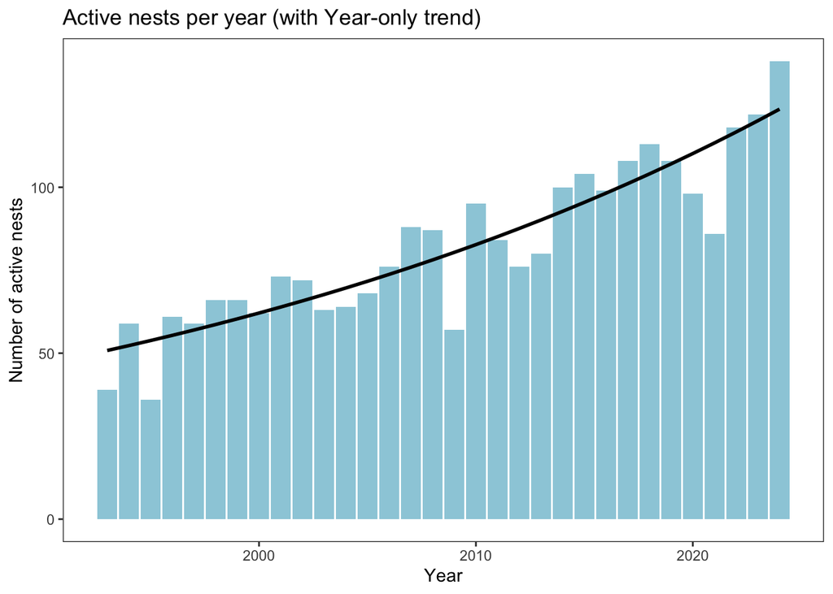

```r
# Plot with fitted line
active.nests$fit_year <- fitted(m_year)

ggplot(active.nests, aes(x = year, y = active_nests)) +
  geom_col(fill = "#89c5d6", alpha = 0.85) +
  geom_line(aes(y = fit_year), linewidth = 1) +
  labs(
    title = "Active nests per year (with Year-only trend)",
    x = "Year",
    y = "Number of active nests"
  ) +
  theme_bw() +
  theme(panel.grid = element_blank())
```

### Rainfall

```r
library(dplyr)

effort_weather <- active.nests |>
  left_join(weather_yearly, by = c("year" = "YEAR")) |>
  mutate(
    z_total_rain = scale(total_rain),
    z_max_rain   = scale(max_rain),
    z_rain_days  = scale(rain_days)
  )

m_rain_only <- MASS::glm.nb(
  active_nests ~ z_total_rain + z_max_rain + z_rain_days,
  data = effort_weather
)
summary(m_rain_only)
```

```
Call:
MASS::glm.nb(formula = active_nests ~ z_total_rain + z_max_rain +
    z_rain_days, data = effort_weather, init.theta = 15.24792259,
    link = log)

Coefficients:
               Estimate Std. Error z value Pr(>|z|)
(Intercept)   4.4025024  0.0493372  89.233   <2e-16 ***
z_total_rain -0.0002133  0.0796258  -0.003    0.998
z_max_rain   -0.0983757  0.0752506  -1.307    0.191
z_rain_days  -0.0188416  0.0543844  -0.346    0.729
---
Signif. codes:  0 '***' 0.001 '**' 0.01 '*' 0.05 '.' 0.1 ' ' 1

(Dispersion parameter for Negative Binomial(15.2479) family taken to be 1)

    Null deviance: 36.176  on 31  degrees of freedom
Residual deviance: 32.431  on 28  degrees of freedom
AIC: 299.52

Number of Fisher Scoring iterations: 1

              Theta:  15.25
          Std. Err.:  4.52

 2 x log-likelihood:  -289.519
```

### Temperature

```r
effort_weather <- effort_weather |>
  mutate(
    z_mean_temp = scale(mean_temp),
    z_max_temp  = scale(max_temp),
    z_min_temp  = scale(min_temp)
  )

m_temp_only <- MASS::glm.nb(
  active_nests ~z_mean_temp+ z_max_temp + z_min_temp,
  data = effort_weather
)
summary(m_temp_only)
```

```
Call:
MASS::glm.nb(formula = active_nests ~ z_mean_temp + z_max_temp +
    z_min_temp, data = effort_weather, init.theta = 16.29562068,
    link = log)

Coefficients:
            Estimate Std. Error z value Pr(>|z|)
(Intercept)  4.40049    0.04800  91.683   <2e-16 ***
z_mean_temp -0.05320    0.06160  -0.864   0.3877
z_max_temp   0.13246    0.05891   2.249   0.0245 *
z_min_temp   0.03381    0.05138   0.658   0.5105
---
Signif. codes:  0 '***' 0.001 '**' 0.01 '*' 0.05 '.' 0.1 ' ' 1

(Dispersion parameter for Negative Binomial(16.2956) family taken to be 1)

    Null deviance: 38.222  on 31  degrees of freedom
Residual deviance: 32.461  on 28  degrees of freedom
AIC: 297.77

Number of Fisher Scoring iterations: 1

              Theta:  16.30
          Std. Err.:  4.90

 2 x log-likelihood:  -287.766
```

Annual breeding effort increased significantly with maximum temperature (β = 0.132 ± 0.059 SE, p = 0.025). Years with higher extreme temperatures had more active nests, whereas mean and minimum temperature showed no significant relationships. The model explained slightly more variation than rainfall-based models (AIC = 297.8 vs. 299.5).

### Wind

```r
effort_weather <- effort_weather |>
  mutate(
    z_mean_wind = scale(mean_wind),
    z_max_wind  = scale(max_wind),
    z_hail_days = scale(hail_days)
  )

m_wind_only <- MASS::glm.nb(
  active_nests ~ z_mean_wind + z_max_wind,
  data = effort_weather
)
summary(m_wind_only)
```

```
Call:
MASS::glm.nb(formula = active_nests ~ z_mean_wind + z_max_wind,
    data = effort_weather, init.theta = 15.33069655, link = log)

Coefficients:
            Estimate Std. Error z value Pr(>|z|)
(Intercept)  4.40243    0.04922  89.438   <2e-16 ***
z_mean_wind -0.06706    0.05215  -1.286    0.199
z_max_wind  -0.05428    0.05231  -1.038    0.299
---
Signif. codes:  0 '***' 0.001 '**' 0.01 '*' 0.05 '.' 0.1 ' ' 1

(Dispersion parameter for Negative Binomial(15.3307) family taken to be 1)

    Null deviance: 36.340  on 31  degrees of freedom
Residual deviance: 32.489  on 29  degrees of freedom
AIC: 297.43

Number of Fisher Scoring iterations: 1

              Theta:  15.33
          Std. Err.:  4.56

 2 x log-likelihood:  -289.431
```

### Hail

```r
effort_weather <- effort_weather |>
  mutate(
    z_mean_wind = scale(mean_wind),
    z_max_wind  = scale(max_wind),
    z_hail_days = scale(hail_days)
  )

m_hail_only <- MASS::glm.nb(
  active_nests ~z_hail_days,
  data = effort_weather
)
summary(m_hail_only)
```

```
Call:
MASS::glm.nb(formula = active_nests ~ z_hail_days, data = effort_weather,
    init.theta = 15.4472834, link = log)

Coefficients:
            Estimate Std. Error z value Pr(>|z|)
(Intercept)  4.40226    0.04907  89.721   <2e-16 ***
z_hail_days  0.09695    0.04926   1.968    0.049 *
---
Signif. codes:  0 '***' 0.001 '**' 0.01 '*' 0.05 '.' 0.1 ' ' 1

(Dispersion parameter for Negative Binomial(15.4473) family taken to be 1)

    Null deviance: 36.569  on 31  degrees of freedom
Residual deviance: 32.511  on 30  degrees of freedom
AIC: 295.25

Number of Fisher Scoring iterations: 1

              Theta:  15.45
          Std. Err.:  4.60

 2 x log-likelihood:  -289.249
```

Annual breeding effort of African White-backed Vultures increased significantly with maximum temperature and with the number of hail days. The rainfall block showed no significant relationships. The best-supported model (lowest AIC = 295.3) included hail days, suggesting that years with more storm activity tended to have greater nesting effort. These relationships likely reflect indirect climatic influences—hotter and stormier years may coincide with improved food availability or with overall population recovery—rather than a direct causal effect of weather on nesting initiation.

### Checking fro correlation

```r
cor(effort_weather[, c("year","hail_days","max_temp")], use="pairwise.complete.obs")
```

```
               year hail_days  max_temp
year      1.0000000 0.3788372 0.3279083
hail_days 0.3788372 1.0000000 0.3291938
max_temp  0.3279083 0.3291938 1.0000000
```

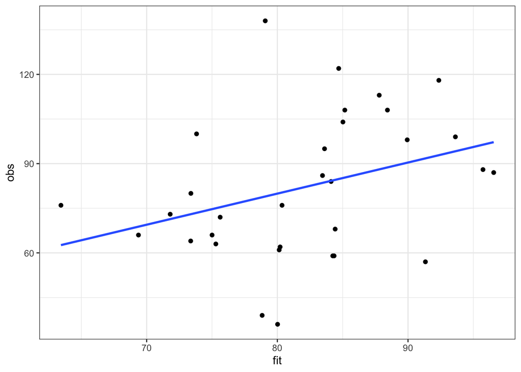

```r
ggplot(data.frame(fit=fitted(m_wind_only), obs=effort_weather$active_nests),
       aes(fit, obs)) + geom_point() + geom_smooth(method="lm", se=FALSE)
```

Both maximum temperature and hail frequency increased modestly through time (r ≈ 0.3–0.4), suggesting that their apparent positive effects on breeding effort may in part reflect the underlying temporal recovery of the vulture population rather than a direct climatic driver.

**Objective 2**

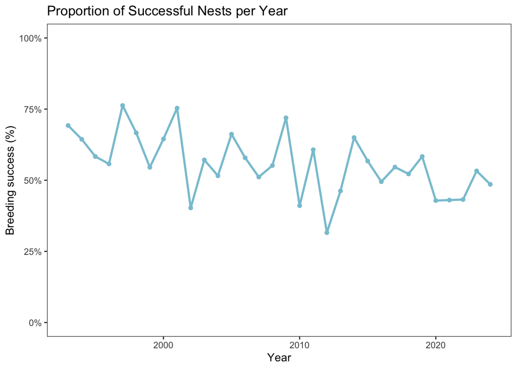

```r
library(dplyr)
library(lubridate)

failed.nests <- vultures.clean |>
  mutate(year = year(ringing.date)) |>
  group_by(year) |>
  summarise(
    active_nests  = n(),
    success_nests = sum(!is.na(laying.date)),      # successful = those with a laying date
    failed_nests  = active_nests - success_nests,
    success_prop  = success_nests / active_nests,
    .groups = "drop"
  )

ggplot(failed.nests, aes(year, success_prop)) +
  geom_line(color = "#89c5d6", linewidth = 1) +
  geom_point(color = "#89c5d6") +
  scale_y_continuous(limits = c(0, 1),
                     labels = scales::percent_format(accuracy = 1)) +
  labs(title = "Proportion of Successful Nests per Year",
       x = "Year", y = "Breeding success (%)") +
  theme_bw() +
  theme(panel.grid = element_blank())
```

### Year only

```r
m_success_year <- glm(
  cbind(success_nests, failed_nests) ~ year,
  family = binomial,
  data = failed.nests
)
summary(m_success_year)
```

```
Call:
glm(formula = cbind(success_nests, failed_nests) ~ year, family = binomial,
    data = failed.nests)

Coefficients:
             Estimate Std. Error z value Pr(>|z|)
(Intercept) 45.434641   8.858715   5.129 2.92e-07 ***
year        -0.022505   0.004405  -5.109 3.24e-07 ***
---
Signif. codes:  0 '***' 0.001 '**' 0.01 '*' 0.05 '.' 0.1 ' ' 1

(Dispersion parameter for binomial family taken to be 1)

    Null deviance: 107.689  on 31  degrees of freedom
Residual deviance:  81.283  on 30  degrees of freedom
AIC: 237.58

Number of Fisher Scoring iterations: 3
```

#### Check for overdispersion

```r
disp_ratio <- deviance(m_success_year) / df.residual(m_success_year)
disp_ratio
```

```
[1] 2.709432
```

(was overdispersed so fitting qausi)

```r
m_success_year <- glm(
  cbind(success_nests, failed_nests) ~ year,
  family = quasibinomial,
  data = failed.nests
)
summary(m_success_year)
```

```
Call:
glm(formula = cbind(success_nests, failed_nests) ~ year, family = quasibinomial,
    data = failed.nests)

Coefficients:
             Estimate Std. Error t value Pr(>|t|)
(Intercept) 45.434641  14.477485   3.138  0.00379 **
year        -0.022505   0.007199  -3.126  0.00391 **
---
Signif. codes:  0 '***' 0.001 '**' 0.01 '*' 0.05 '.' 0.1 ' ' 1

(Dispersion parameter for quasibinomial family taken to be 2.670821)

    Null deviance: 107.689  on 31  degrees of freedom
Residual deviance:  81.283  on 30  degrees of freedom
AIC: NA

Number of Fisher Scoring iterations: 3
```

### Rainfall

```r
success_df <- failed.nests |>
  left_join(weather_yearly, by = c("year" = "YEAR")) |>
  mutate(
    z_total_rain = scale(total_rain),
    z_max_rain   = scale(max_rain),
    z_rain_days  = scale(rain_days)
  )
```

```r
m_success_rain <- glm(
  cbind(success_nests, failed_nests) ~
    z_total_rain + z_max_rain + z_rain_days,
  family = quasibinomial,
  data = success_df
)
summary(m_success_rain)
```

```
Call:
glm(formula = cbind(success_nests, failed_nests) ~ z_total_rain +
    z_max_rain + z_rain_days, family = quasibinomial, data = success_df)

Coefficients:
             Estimate Std. Error t value Pr(>|t|)
(Intercept)   0.17862    0.07543   2.368    0.025 *
z_total_rain -0.04284    0.13109  -0.327    0.746
z_max_rain    0.06474    0.12323   0.525    0.603
z_rain_days  -0.03705    0.08314  -0.446    0.659
---
Signif. codes:  0 '***' 0.001 '**' 0.01 '*' 0.05 '.' 0.1 ' ' 1

(Dispersion parameter for quasibinomial family taken to be 3.663694)

    Null deviance: 107.69  on 31  degrees of freedom
Residual deviance: 105.11  on 28  degrees of freedom
AIC: NA

Number of Fisher Scoring iterations: 3
```

Annual breeding success showed no relationship with rainfall variables. Neither total annual precipitation, maximum daily rainfall, nor the number of rainy days explained variation in the proportion of successful nests (all p > 0.6). The rainfall model accounted for little additional deviance relative to the null model.

### Temperature

```r
success_df <- success_df |>
  mutate(
    z_mean_temp = scale(mean_temp),
    z_max_temp  = scale(max_temp),
    z_min_temp  = scale(min_temp)
  )
```

```r
m_success_temp <- glm(
  cbind(success_nests, failed_nests) ~
z_min_temp,
  family = quasibinomial,
  data = success_df
)
summary(m_success_temp)
```

```
Call:
glm(formula = cbind(success_nests, failed_nests) ~ z_min_temp,
    family = quasibinomial, data = success_df)

Coefficients:
            Estimate Std. Error t value Pr(>|t|)
(Intercept)  0.17203    0.06845   2.513   0.0176 *
z_min_temp   0.16071    0.07298   2.202   0.0355 *
---
Signif. codes:  0 '***' 0.001 '**' 0.01 '*' 0.05 '.' 0.1 ' ' 1

(Dispersion parameter for quasibinomial family taken to be 3.031978)

    Null deviance: 107.689  on 31  degrees of freedom
Residual deviance:  92.877  on 30  degrees of freedom
AIC: NA

Number of Fisher Scoring iterations: 3
```

```r
m_success_temp <- glm(
  cbind(success_nests, failed_nests) ~
   z_max_temp,
  family = quasibinomial,
  data = success_df
)
summary(m_success_temp)
```

```
Call:
glm(formula = cbind(success_nests, failed_nests) ~ z_max_temp,
    family = quasibinomial, data = success_df)

Coefficients:
            Estimate Std. Error t value Pr(>|t|)
(Intercept)  0.18310    0.07308   2.506   0.0179 *
z_max_temp  -0.06103    0.07114  -0.858   0.3977
---
Signif. codes:  0 '***' 0.001 '**' 0.01 '*' 0.05 '.' 0.1 ' ' 1

(Dispersion parameter for quasibinomial family taken to be 3.43318)

    Null deviance: 107.69  on 31  degrees of freedom
Residual deviance: 105.16  on 30  degrees of freedom
AIC: NA

Number of Fisher Scoring iterations: 3
```

```r
 m_success_temp <- glm(
  cbind(success_nests, failed_nests) ~
    z_mean_temp,
  family = quasibinomial,
  data = success_df
)
summary(m_success_temp)
```

```
Call:
glm(formula = cbind(success_nests, failed_nests) ~ z_mean_temp,
    family = quasibinomial, data = success_df)

Coefficients:
            Estimate Std. Error t value Pr(>|t|)
(Intercept)  0.17461    0.07272   2.401   0.0227 *
z_mean_temp  0.05587    0.07149   0.781   0.4406
---
Signif. codes:  0 '***' 0.001 '**' 0.01 '*' 0.05 '.' 0.1 ' ' 1

(Dispersion parameter for quasibinomial family taken to be 3.437201)

    Null deviance: 107.69  on 31  degrees of freedom
Residual deviance: 105.59  on 30  degrees of freedom
AIC: NA

Number of Fisher Scoring iterations: 3
```

Minimum temperature showed a significant positive relationship with breeding success (β = 0.161 ± 0.073 SE, p = 0.036). Years with warmer minimum (night-time) temperatures had higher proportions of successful nests, suggesting that milder conditions during the breeding season may improve chick survival. Neither mean nor maximum temperature showed significant effects (both p > 0.3). These results indicate that low overnight temperatures, rather than daytime heat extremes, are more influential in determining annual breeding success.

### Wind

```r
success_df <- success_df |>
  mutate(
    z_mean_wind = scale(mean_wind),
    z_max_wind  = scale(max_wind),
    z_hail_days = scale(hail_days)
  )
```

```r
m_success_wind <- glm(
  cbind(success_nests, failed_nests) ~
    z_mean_wind + z_max_wind,
  family = quasibinomial,
  data = success_df
)
summary(m_success_wind)
```

```
Call:
glm(formula = cbind(success_nests, failed_nests) ~ z_mean_wind +
    z_max_wind, family = quasibinomial, data = success_df)

Coefficients:
            Estimate Std. Error t value Pr(>|t|)
(Intercept)  0.17646    0.07497   2.354   0.0256 *
z_mean_wind  0.01436    0.07952   0.181   0.8579
z_max_wind  -0.01688    0.08283  -0.204   0.8399
---
Signif. codes:  0 '***' 0.001 '**' 0.01 '*' 0.05 '.' 0.1 ' ' 1

(Dispersion parameter for quasibinomial family taken to be 3.62518)

    Null deviance: 107.69  on 31  degrees of freedom
Residual deviance: 107.48  on 29  degrees of freedom
AIC: NA

Number of Fisher Scoring iterations: 3
```

### Hail

```r
m_success_hail<- glm(
  cbind(success_nests, failed_nests) ~
    z_hail_days,
  family = quasibinomial,
  data = success_df
)
summary(m_success_hail)
```

```
Call:
glm(formula = cbind(success_nests, failed_nests) ~ z_hail_days,
    family = quasibinomial, data = success_df)

Coefficients:
            Estimate Std. Error t value Pr(>|t|)
(Intercept)  0.18275    0.07291   2.506   0.0179 *
z_hail_days -0.05984    0.06750  -0.887   0.3824
---
Signif. codes:  0 '***' 0.001 '**' 0.01 '*' 0.05 '.' 0.1 ' ' 1

(Dispersion parameter for quasibinomial family taken to be 3.424453)

    Null deviance: 107.69  on 31  degrees of freedom
Residual deviance: 105.00  on 30  degrees of freedom
AIC: NA

Number of Fisher Scoring iterations: 3
```

Neither wind speed nor hail frequency showed a significant relationship with breeding success. Both mean and maximum wind speeds had negligible effects (p > 0.8), and the number of hail days was also unrelated to success (p = 0.38). These findings suggest that annual variation in wind intensity and storm activity does not strongly influence the proportion of successful nests.

**Objective 3**

```r
timing_df <- vultures.clean |>
  filter(!is.na(laying.date)) |>
  mutate(
    year    = year(laying.date),
    lay_DOY = yday(laying.date)
  )
```

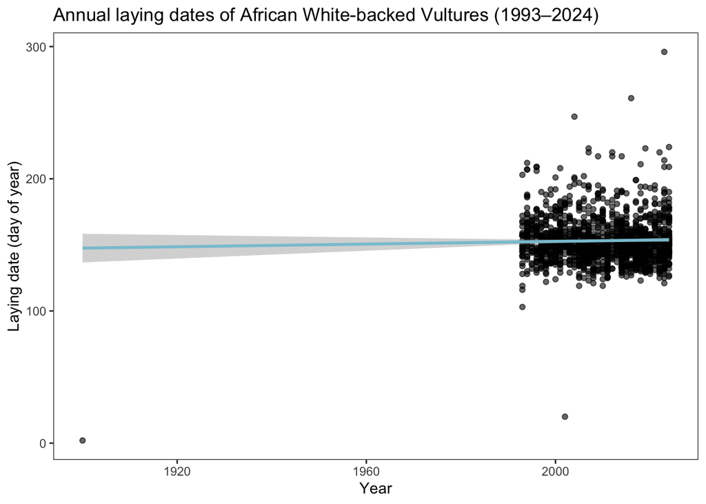

```r
ggplot(timing_df, aes(year, lay_DOY)) +
  geom_point(alpha = 0.6) +
  geom_smooth(method = "lm", se = TRUE, colour = "#89c5d6") +
  labs(title = "Annual laying dates of African White-backed Vultures (1993–2024)",
       x = "Year", y = "Laying date (day of year)") +
  theme_bw() +
  theme(panel.grid = element_blank())
```

### Year only

```r
m_timing_year <- lm(lay_DOY ~ year, data = timing_df)
summary(m_timing_year)
```

```
Call:
lm(formula = lay_DOY ~ year, data = timing_df)

Residuals:
     Min       1Q   Median       3Q      Max
-145.550  -10.926   -2.806    7.466  142.212

Coefficients:
             Estimate Std. Error t value Pr(>|t|)
(Intercept)  51.19784  100.72615   0.508    0.611
year          0.05071    0.05011   1.012    0.312

Residual standard error: 18.18 on 1426 degrees of freedom
Multiple R-squared:  0.0007176, Adjusted R-squared:  1.688e-05
F-statistic: 1.024 on 1 and 1426 DF,  p-value: 0.3117
```

Laying dates did not change significantly between 1993 and 2024 (β = 0.051 ± 0.050 SE, p = 0.31). The slope indicates a very slight shift toward later laying (about 0.05 days per year, or roughly 1.5 days over three decades), but this trend is negligible and statistically non-significant (R² < 0.001). Overall, laying timing appears stable through time.

### Rainfall

```r
timing_weather <- timing_df |>
  left_join(weather_yearly, by = c("year" = "YEAR")) |>
  mutate(
    z_total_rain = scale(total_rain),
    z_max_rain   = scale(max_rain),
    z_rain_days  = scale(rain_days)
  )
```

```r
m_timing_rain <- lm(
  lay_DOY ~ z_total_rain + z_max_rain + z_rain_days,
  data = timing_weather
)
summary(m_timing_rain)
```

```
Call:
lm(formula = lay_DOY ~ z_total_rain + z_max_rain + z_rain_days,
    data = timing_weather)

Residuals:
     Min       1Q   Median       3Q      Max
-133.124  -10.878   -2.867    7.122  143.370

Coefficients:
             Estimate Std. Error t value Pr(>|t|)
(Intercept)  153.2348     0.4693 326.500   <2e-16 ***
z_total_rain   1.2743     0.7057   1.806   0.0712 .
z_max_rain    -0.3413     0.6682  -0.511   0.6096
z_rain_days   -0.8707     0.5211  -1.671   0.0949 .
---
Signif. codes:  0 '***' 0.001 '**' 0.01 '*' 0.05 '.' 0.1 ' ' 1

Residual standard error: 17.73 on 1423 degrees of freedom
  (1 observation deleted due to missingness)
Multiple R-squared:  0.00381,   Adjusted R-squared:  0.00171
F-statistic: 1.814 on 3 and 1423 DF,  p-value: 0.1427
```

Annual rainfall showed no significant effect on the timing of laying (F(3,1423) = 1.81, p = 0.14). Although wetter years tended to correspond weakly with slightly later laying (β_total_rain = +1.27, p = 0.07) and more rainy days with earlier laying (β_rain_days = −0.87, p = 0.09), neither effect was statistically significant. Overall, rainfall explained less than 0.5% of the variation in laying dates (R² = 0.004), indicating that breeding timing remained stable regardless of annual rainfall conditions.

### Temperature

```r
timing_weather <- timing_weather |>
  mutate(
    z_mean_temp = scale(mean_temp),
    z_max_temp  = scale(max_temp),
    z_min_temp  = scale(min_temp)
  )
```

```r
m_timing_temp <- lm(
  lay_DOY ~ z_mean_temp + z_max_temp + z_min_temp,
  data = timing_weather
)
summary(m_timing_temp)
```

```
Call:
lm(formula = lay_DOY ~ z_mean_temp + z_max_temp + z_min_temp,
    data = timing_weather)

Residuals:
     Min       1Q   Median       3Q      Max
-133.970  -10.838   -2.714    7.080  143.309

Coefficients:
             Estimate Std. Error t value Pr(>|t|)
(Intercept) 153.23476    0.46904 326.702   <2e-16 ***
z_mean_temp   0.30497    0.59797   0.510   0.6101
z_max_temp    0.04814    0.57500   0.084   0.9333
z_min_temp   -1.31971    0.49368  -2.673   0.0076 **
---
Signif. codes:  0 '***' 0.001 '**' 0.01 '*' 0.05 '.' 0.1 ' ' 1

Residual standard error: 17.72 on 1423 degrees of freedom
  (1 observation deleted due to missingness)
Multiple R-squared:  0.00504,   Adjusted R-squared:  0.002942
F-statistic: 2.403 on 3 and 1423 DF,  p-value: 0.066
```

Minimum temperature showed a significant negative relationship with laying date (β = –1.32 ± 0.49 SE, p = 0.008), indicating that vultures bred earlier in years with warmer nights. Mean and maximum temperature had no effect (p > 0.6). Overall, the model explained little of the total variation (R² = 0.005), but the direction of the effect suggests that milder nocturnal conditions may trigger earlier laying.

### Wind

```r
timing_weather <- timing_weather |>
  mutate(
    z_mean_wind = scale(mean_wind),
    z_max_wind  = scale(max_wind),
    z_hail_days = scale(hail_days)
  )
```

```r
m_timing_wind <- lm(
  lay_DOY ~ z_mean_wind + z_max_wind,
  data = timing_weather
)
summary(m_timing_wind)
```

```
Call:
lm(formula = lay_DOY ~ z_mean_wind + z_max_wind, data = timing_weather)

Residuals:
     Min       1Q   Median       3Q      Max
-135.203  -10.502   -2.926    7.498  143.503

Coefficients:
            Estimate Std. Error t value Pr(>|t|)
(Intercept) 153.2348     0.4680 327.419  < 2e-16 ***
z_mean_wind   0.7328     0.4828   1.518  0.12922
z_max_wind    1.3159     0.4828   2.726  0.00649 **
---
Signif. codes:  0 '***' 0.001 '**' 0.01 '*' 0.05 '.' 0.1 ' ' 1

Residual standard error: 17.68 on 1424 degrees of freedom
  (1 observation deleted due to missingness)
Multiple R-squared:  0.008699,  Adjusted R-squared:  0.007307
F-statistic: 6.248 on 2 and 1424 DF,  p-value: 0.001987
```

Maximum wind speed had a significant positive relationship with laying date (β = +1.32 ± 0.48 SE, p = 0.006), indicating that vultures tended to lay later in windier years. Mean wind speed showed no effect (p = 0.13). Although wind explained less than 1 % of the total variation in laying dates (R² = 0.009), the direction of the effect suggests that stronger winds may delay breeding, potentially by reducing flight efficiency or nest stability during the early season.

### Hail

```r
m_timing_hail <- lm(
  lay_DOY ~ z_hail_days,
  data = timing_weather
)
summary(m_timing_hail)
```

```
Call:
lm(formula = lay_DOY ~ z_hail_days, data = timing_weather)

Residuals:
     Min       1Q   Median       3Q      Max
-133.281  -10.934   -2.628    7.852  142.066

Coefficients:
            Estimate Std. Error t value Pr(>|t|)
(Intercept) 153.2348     0.4692 326.598   <2e-16 ***
z_hail_days  -0.9732     0.4693  -2.073   0.0383 *
---
Signif. codes:  0 '***' 0.001 '**' 0.01 '*' 0.05 '.' 0.1 ' ' 1

Residual standard error: 17.72 on 1425 degrees of freedom
  (1 observation deleted due to missingness)
Multiple R-squared:  0.003008,  Adjusted R-squared:  0.002308
F-statistic: 4.299 on 1 and 1425 DF,  p-value: 0.03831
```

The number of hail days showed a significant negative relationship with laying date (β = –0.97 ± 0.47 SE, p = 0.038). Vultures laid earlier in years with more hail events, suggesting that stormier seasons may coincide with conditions prompting earlier breeding. Although the overall effect size was small (R² = 0.003), this pattern supports the idea that extreme-weather activity may influence breeding timing.

Summary of results

```r
library(tibble)
library(dplyr)
library(knitr)

sig_summary <- tribble(
  ~Objective,               ~Response,                         ~Predictor,          ~Direction,        ~p_value, ~Interpretation,
  "1. Breeding effort",     "Active nests (NB GLM)",           "Max temperature",   "Positive (↑)",    0.025,   "More active nests in hotter years.",
  "1. Breeding effort",     "Active nests (NB GLM)",           "Hail days",         "Positive (↑)",    0.049,   "More active nests in years with more hail.",
  "2. Breeding success",    "Success proportion (quasi-bin)",  "Min temperature",   "Positive (↑)",    0.036,   "Higher success in warmer nights.",
  "3. Breeding timing",     "Laying date DOY (LM)",            "Min temperature",   "Negative (↓)",    0.008,   "Warmer nights → earlier laying.",
  "3. Breeding timing",     "Laying date DOY (LM)",            "Max wind speed",    "Positive (↑)",    0.006,   "Windier years → later laying.",
  "3. Breeding timing",     "Laying date DOY (LM)",            "Hail days",         "Negative (↓)",    0.038,   "More hail → earlier laying."
)

kable(sig_summary, align = "l")
```

| Objective | Response | Predictor | Direction | p_value | Interpretation |
| --- | --- | --- | --- | --- | --- |
| 1. Breeding effort | Active nests (NB GLM) | Max temperature | Positive (↑) | 0.025 | More active nests in hotter years. |
| 1. Breeding effort | Active nests (NB GLM) | Hail days | Positive (↑) | 0.049 | More active nests in years with more hail. |
| 2. Breeding success | Success proportion (quasi-bin) | Min temperature | Positive (↑) | 0.036 | Higher success in warmer nights. |
| 3. Breeding timing | Laying date DOY (LM) | Min temperature | Negative (↓) | 0.008 | Warmer nights → earlier laying. |
| 3. Breeding timing | Laying date DOY (LM) | Max wind speed | Positive (↑) | 0.006 | Windier years → later laying. |
| 3. Breeding timing | Laying date DOY (LM) | Hail days | Negative (↓) | 0.038 | More hail → earlier laying. |